# Smaller landsape testing

### Heterogeneity in single mutational effects (SMEs)

The spread of functional contributions of the positions. This shows whether introducing a mutation in a given position impacts the function positively or negatively (or neutral) across all backgrounds

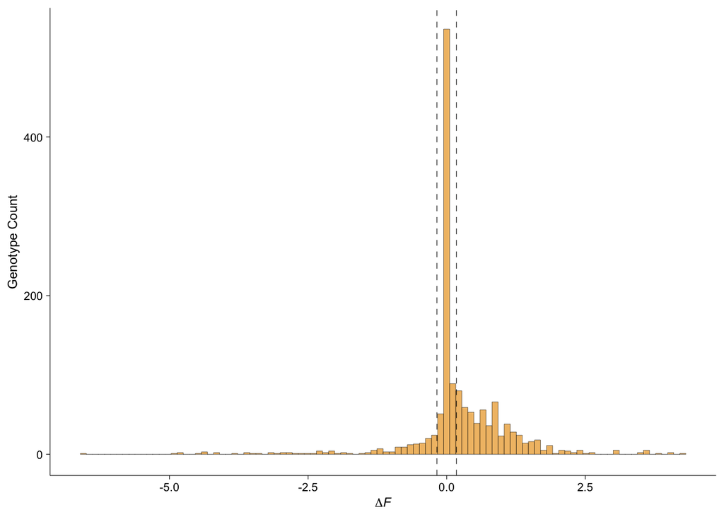

#### Spread in SMEs - 2SD

We have 57 positions.

##### Histogram of 2SD - SMEs

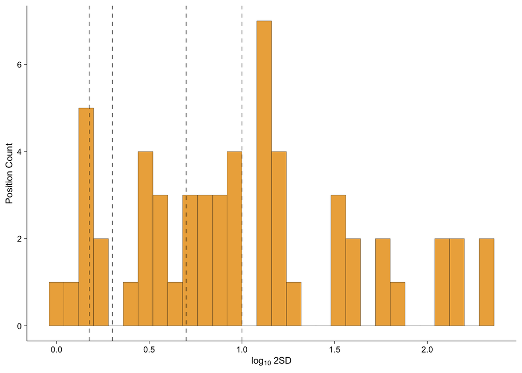

##### Table of 2SD - SMEs

First order positions which have a heterogeneity index > log10 1.5-fold, 2-fold, 5-fold, and 10-fold for adaptive trajectories

| mutations | idiosync_sig_1.5 | idiosync_sig_2 | idiosync_sig_5 | idiosync_sig_10 | idiosync_total | idiosync_1.5 | idiosync_2 | idiosync_5 | idiosync_10 |
| --- | --- | --- | --- | --- | --- | --- | --- | --- | --- |
| Order 1 | 51 | 48 | 38 | 26 | 57 | 89.47368 | 84.21053 | 66.66667 | 45.61404 |

#### Spread in SMEs - sign

We assign positive, neutral, negative, negative-neutral, positive-neutral, and negative-positive ‘types’ based on log10 1.5-fold threshold to every order

##### Piechart of sign - SMEs

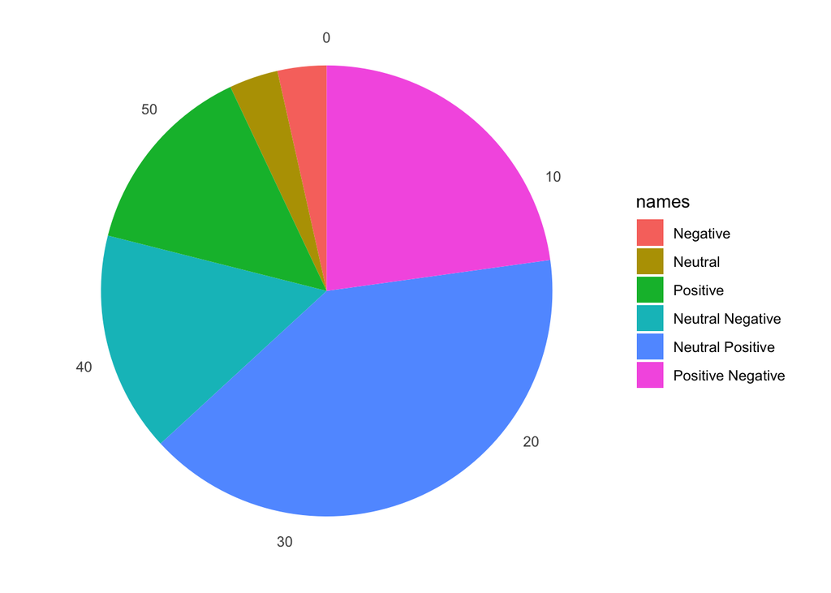

Note, the aesthetics of the pie charts were edited elsewhere for publication.

##### Table of sign - SMEs and EEs

Raw Values

[output not shown]

| mutations | Negative | Neutral | Neutral Negative | Neutral Positive | Positive | Positive Negative | Total |
| --- | --- | --- | --- | --- | --- | --- | --- |
| Order 1 | 2 | 2 | 9 | 23 | 8 | 13 | 57 |
| Order 2 | 0 | 3 | 21 | 29 | 5 | 66 | 124 |
| Order 3 | 7 | 4 | 28 | 27 | 7 | 74 | 147 |
| Order 4 | 7 | 1 | 18 | 20 | 5 | 49 | 100 |
| Order 5 | 5 | 2 | 9 | 8 | 3 | 12 | 39 |
| Order 6 | 0 | 0 | 3 | 2 | 1 | 1 | 7 |

Percentages

| mutations | Negative | Neutral | Neutral Negative | Neutral Positive | Positive | Positive Negative | Total |
| --- | --- | --- | --- | --- | --- | --- | --- |
| Order 1 | 3.508772 | 3.508772 | 15.78947 | 40.35088 | 14.035088 | 22.80702 | 57 |
| Order 2 | 0.000000 | 2.419355 | 16.93548 | 23.38710 | 4.032258 | 53.22581 | 124 |
| Order 3 | 4.761905 | 2.721088 | 19.04762 | 18.36735 | 4.761905 | 50.34014 | 147 |
| Order 4 | 7.000000 | 1.000000 | 18.00000 | 20.00000 | 5.000000 | 49.00000 | 100 |
| Order 5 | 12.820513 | 5.128205 | 23.07692 | 20.51282 | 7.692308 | 30.76923 | 39 |
| Order 6 | 0.000000 | 0.000000 | 42.85714 | 28.57143 | 14.285714 | 14.28571 | 7 |

#### Spread in SMEs - wt/mean dev

The purpose of this analysis was to determine the difference in SMEs between the WT-background contribution of a given position/combination and the mean contribution of a given position or combination

##### Histogram of wt/mean dev - SMEs

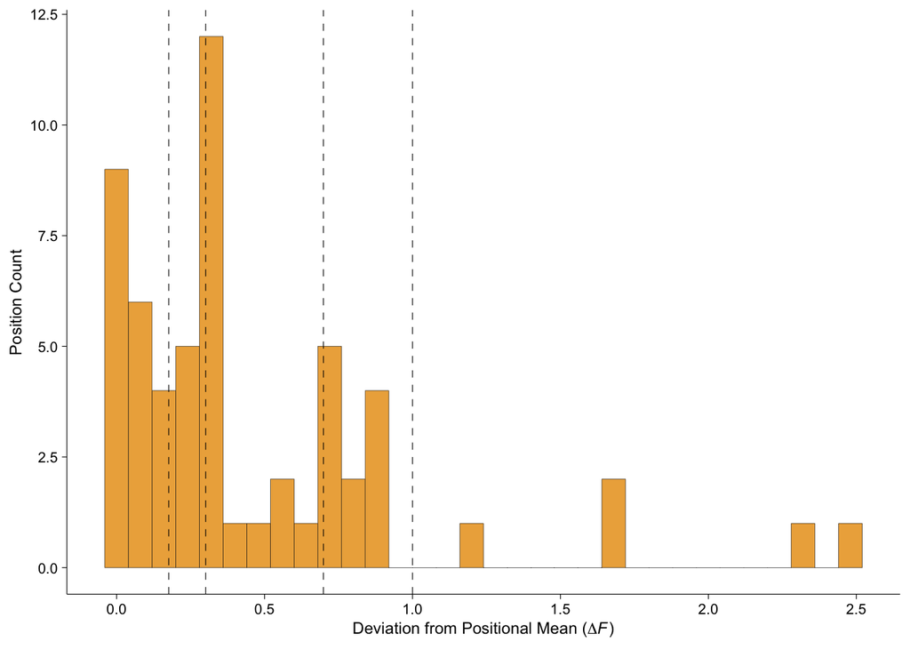

In the manuscript, we also briefly mentioned how many WT SMEs have sign deviation (not just magnitude) from the mean at the 1st order. This is in fact 0% (0/57).

##### Table of wt/mean dev - SMEs

Also, in the supplementary of our paper, we show this table to show percentages of WT-bg points that deviate from the positional/combinatorial mean by multiple significance threshold (log10 1.5-, 2-, 5-, and 10-fold)

| Order | percent_1.5 | outlier_1.5 | percent_2 | outlier_2 | percent_5 | outlier_5 | percent_10 | outlier_10 | total |
| --- | --- | --- | --- | --- | --- | --- | --- | --- | --- |
| 1 | 70.2 | 40 | 52.6 | 30 | 26.3 | 15 | 8.8 | 5 | 57 |
| 2 | 46.8 | 58 | 37.1 | 46 | 12.9 | 16 | 5.6 | 7 | 124 |
| 3 | 38.1 | 56 | 22.4 | 33 | 5.4 | 8 | 2.7 | 4 | 147 |
| 4 | 51.0 | 51 | 35.0 | 35 | 15.0 | 15 | 7.0 | 7 | 100 |

As well as the devation of every single SME and EE from the mean, instead of just the wt background.

##### Table of all SME and EE to mean dev

| Order | percent_1.5 | outlier_1.5 | percent_2 | outlier_2 | percent_5 | outlier_5 | percent_10 | outlier_10 | total |
| --- | --- | --- | --- | --- | --- | --- | --- | --- | --- |
| 1 | 0.5395833 | 777 | 0.3770833 | 543 | 0.1069444 | 154 | 0.0493056 | 71 | 1440 |
| 2 | 0.4355381 | 777 | 0.2813901 | 502 | 0.0852018 | 152 | 0.0369955 | 66 | 1784 |
| 3 | 0.4166667 | 510 | 0.2459150 | 301 | 0.0686275 | 84 | 0.0334967 | 41 | 1224 |
| 4 | 0.4900000 | 245 | 0.3020000 | 151 | 0.0800000 | 40 | 0.0340000 | 17 | 500 |

### Heterogeneity in epistatic effects

#### Spread in EEs - 2SD

Histogram to show heterogenity at Orders 2, 3, and 4 with the log10 1.5-fold significance threshold

##### Histogram of 2SD - pairwise

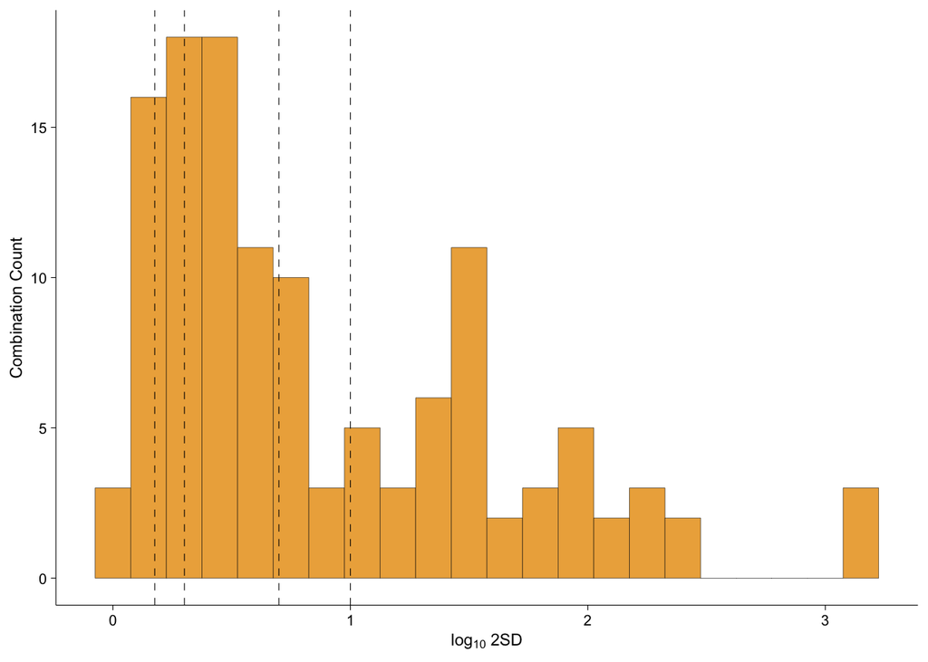

##### Histogram of 2SD - three-way

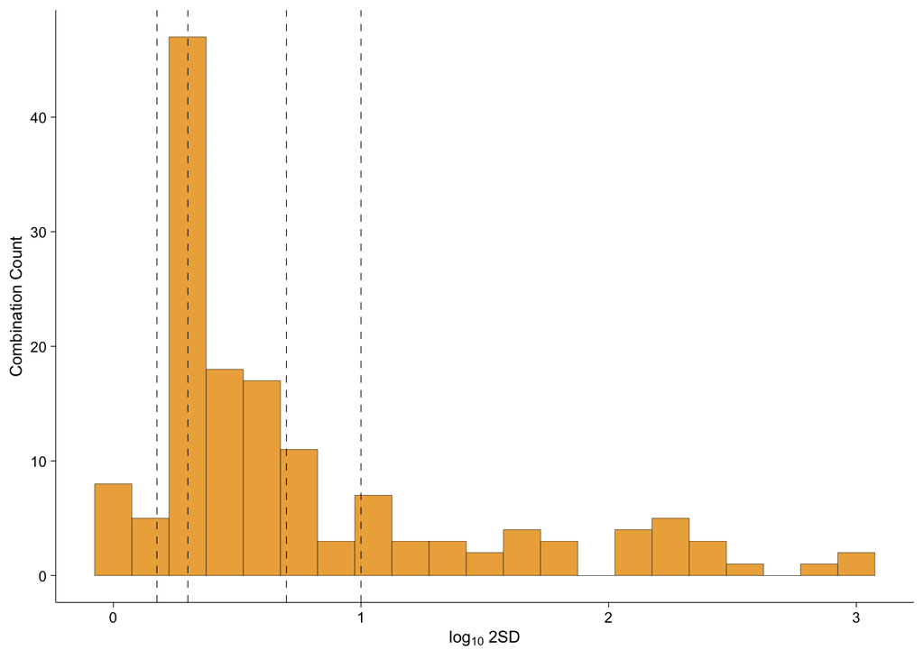

##### Histogram of 2SD - four-way

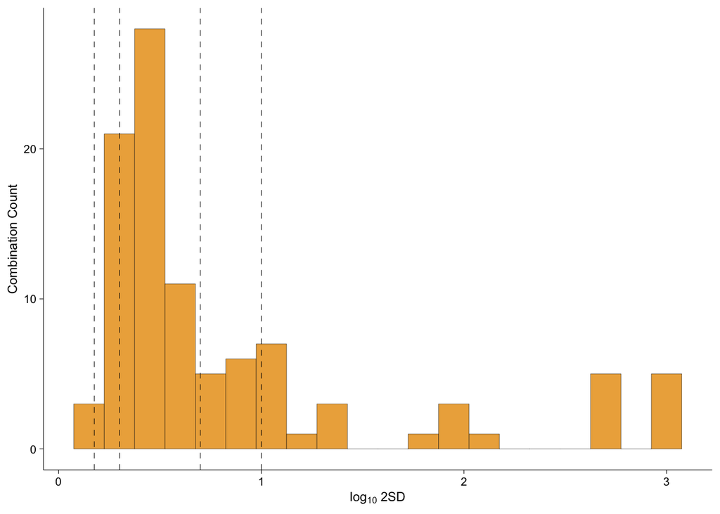

##### Table of 2SD in all EEs - Extended data table 1

What percentage of positions remain significantly heterogeneous (1.5-, 2-, 5-, and 10-fold) at all orders?

| mutations | idiosync_sig_1.5 | idiosync_sig_2 | idiosync_sig_5 | idiosync_sig_10 | idiosync_total | idiosync_1.5 | idiosync_2 | idiosync_5 | idiosync_10 |
| --- | --- | --- | --- | --- | --- | --- | --- | --- | --- |
| Order 1 | 51 | 48 | 38 | 26 | 57 | 89.47368 | 84.21053 | 66.66667 | 45.61404 |
| Order 2 | 114 | 94 | 56 | 44 | 124 | 91.93548 | 75.80645 | 45.16129 | 35.48387 |
| Order 3 | 135 | 112 | 51 | 37 | 147 | 91.83673 | 76.19048 | 34.69388 | 25.17007 |
| Order 4 | 99 | 85 | 37 | 20 | 100 | 99.00000 | 85.00000 | 37.00000 | 20.00000 |

#### Spread in EEs - sign

##### Piechart of sign - EE pairiwise

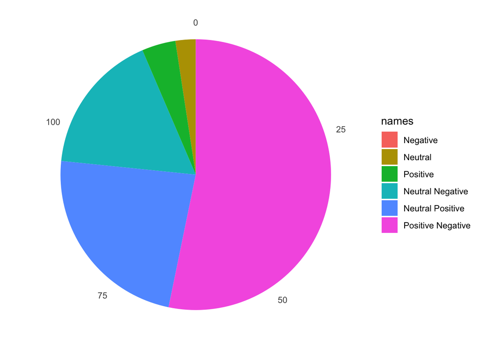

##### Piechart of sign - EE three-way

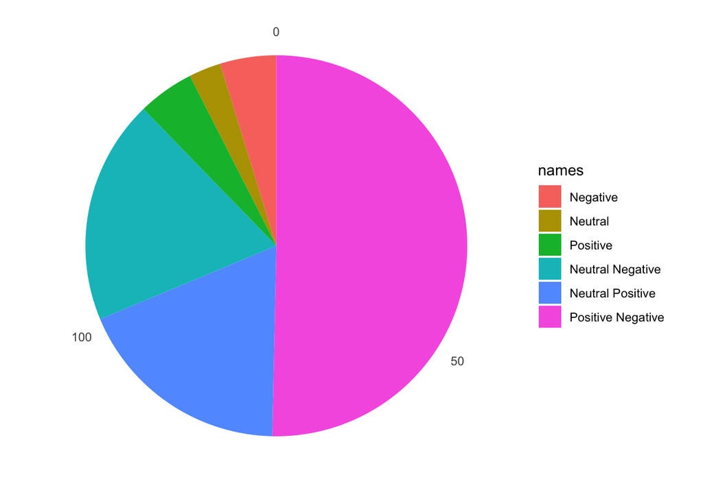

##### Piechart of sign - EE four-way

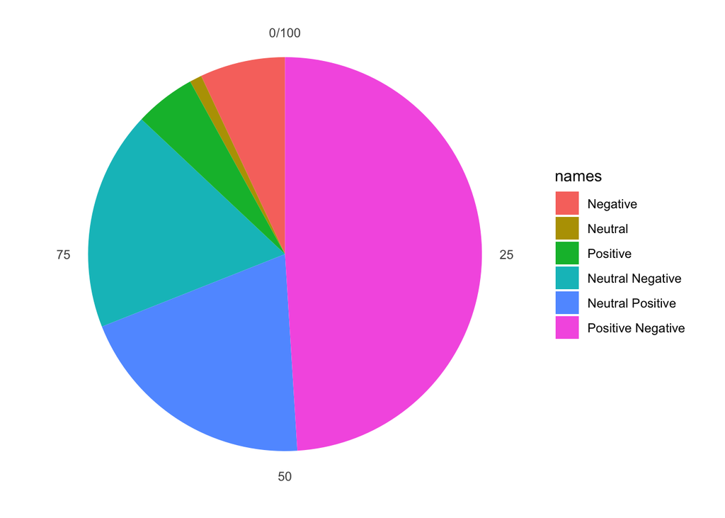

#### Spread in EEs - wt/mean dev

##### Histogram of wt/mean dev - pairwise EEs

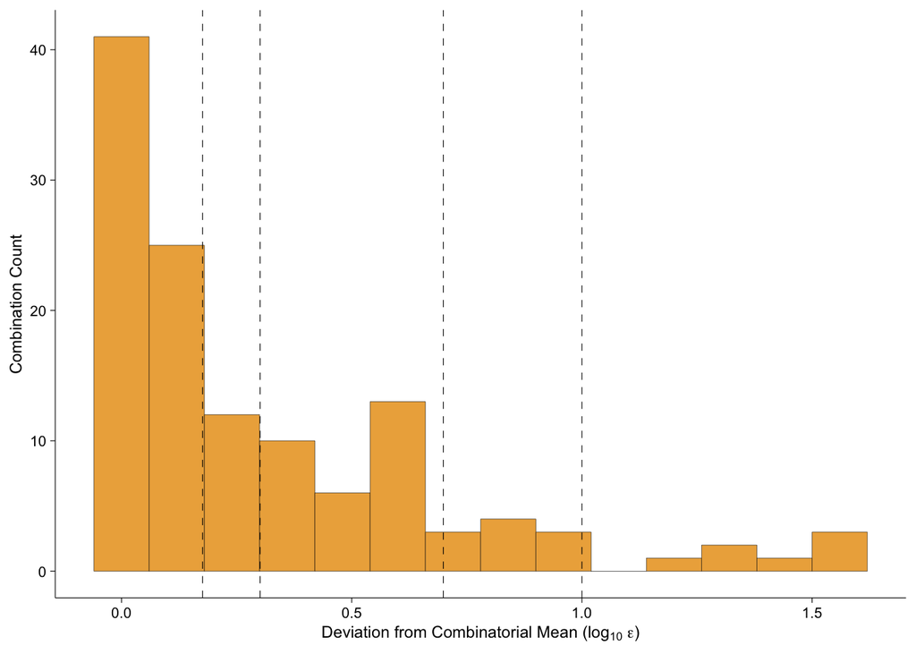

##### Histogram of wt/mean dev - three-way EEs

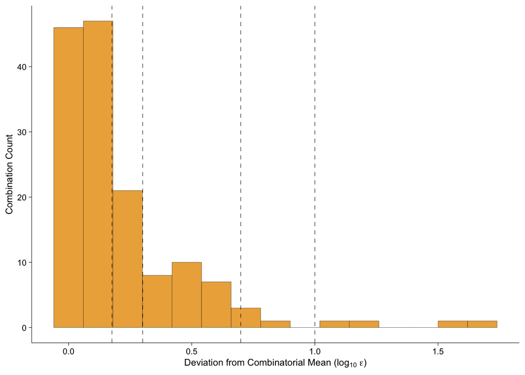

##### Histogram of wt/mean dev - four-way EEs

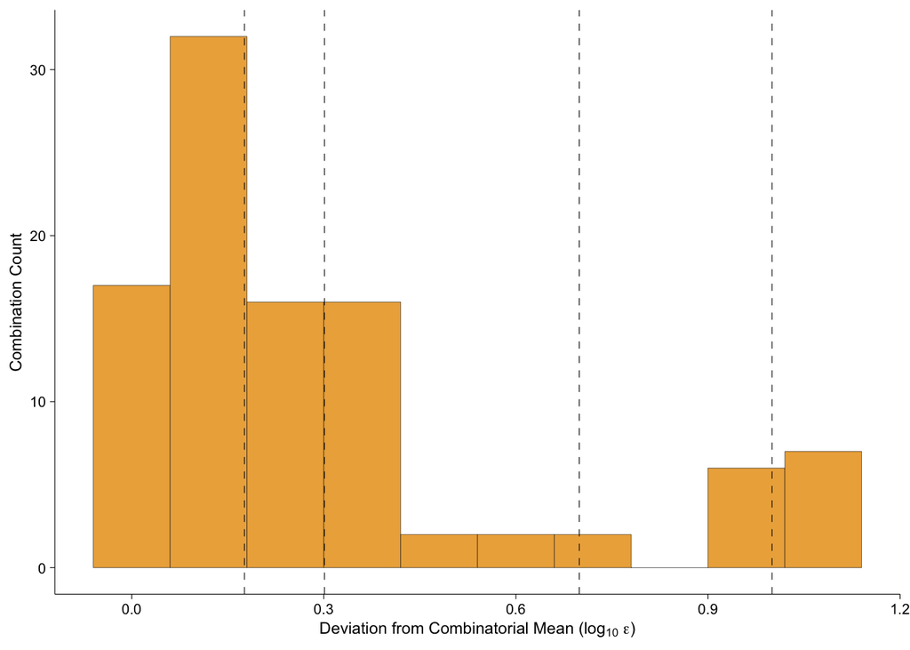

Like the SMEs, we checked whether there is a sign deviation between the wt EE and mean EE at each order of interaction. For pairwise we saw 8/124 (6.45%). For three-way we saw 2/147 (1.36%). For four-way we saw 4/100 (4%).

### Prediction of end-points

Import the absolute error files for each data set

How well does each model predict at each order

| Step | wtbg_mean | wtbg_median | lin_mean | lin_median |
| --- | --- | --- | --- | --- |
| 1 | 69.504769 | 14.558852 | 2.173860 | 1.777802 |
| 2 | 64.441916 | 18.943208 | 1.788405 | 2.181867 |
| 3 | 6.043751 | 3.920920 | 1.126402 | 1.054406 |
| 4 | 15.926417 | 17.105252 | 1.070453 | 1.052464 |
| 5 | 2.654475 | 3.210355 | 1.016186 | 1.019386 |
| 6 | 2.603822 | 2.603822 | 1.007567 | 1.007567 |

Are the means significantly less than 1.5-fold?

| Step | wtbg_pval | lin_mean |
| --- | --- | --- |
| 1 | 0.9925409 | 0.9460648 |
| 2 | 0.9994126 | 0.8897631 |
| 3 | 0.9853900 | 0.0000207 |
| 4 | 0.9978066 | 0.0000002 |

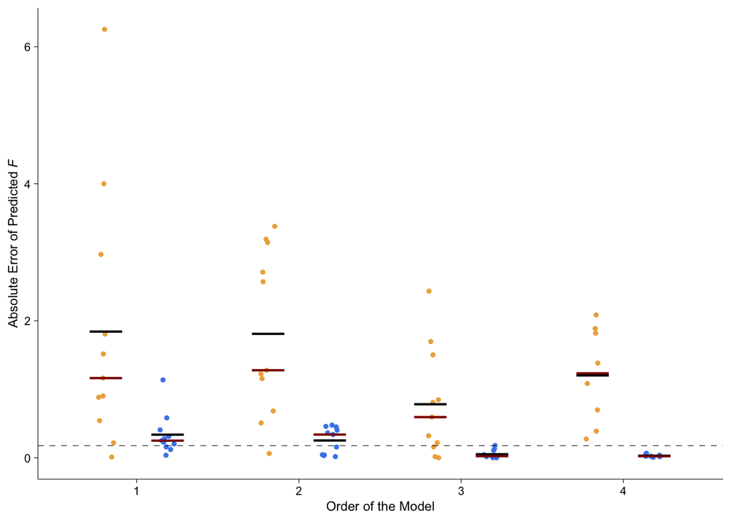

This plot omits some data from being viewed, however plotted means and medians are accurate. The figure is edited outside of the code for aesthetics.

### Prediction of intermediates

Instead of predicting end point variants, we can look at how the biochemical model predicts variants along the most accessible trajectory by monitoring AE for the predicted function of each intermediate. The x-axis represent the order of the intermediate mutant that is being predicted along the most accessible trajectory.

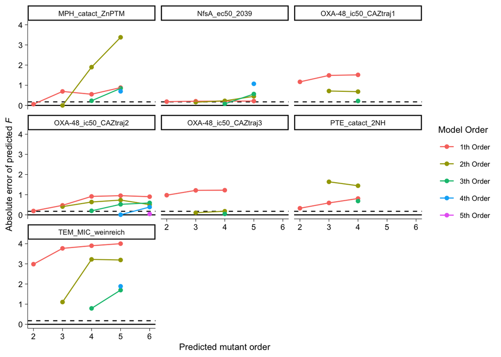

### Network rewiring

First we load the required data for network rewiring exploration, as well as establish filters for adaptive trajectories and ‘mechanistic’ trajectories.

Then we look at how many network rewiring events there are.

| epistasis at lower-order? | epistasis at higher-order? | n | percentage |
| --- | --- | --- | --- |
| FALSE | FALSE | 55 | 17.13396 |
| FALSE | TRUE | 75 | 23.36449 |
| TRUE | FALSE | 50 | 15.57632 |
| TRUE | TRUE | 141 | 43.92523 |

Of the rewired, how many are constructive and how many are disruptive?

| event_type | n | percentage |
| --- | --- | --- |
| constructive | 41 | 29.07801 |
| disruptive | 100 | 70.92199 |

### Molecular basis

This analysis was bespoke, but surveying all network rewiring events manually and selecting genotypes along adaptive trajectories.